# Part II - Airline Delay Cause

## by Vamshi Krishna Reddy Singireddy

## Investigation Overview

The goal is to show the major causes of flight delay. The relation between these reasons was explored. There are outside factors that influence the delay as number of flights can directly impact the air traffic. There shouldn't much difference in frequency of flights unless the routes are stopped due to a business reason or due to external events like a pandemic or economic downturn. We also found there is high correlation between different delay reasons.

## Dataset Overview

The dataset is maitained by U.S. Department of Transportation with data reported by airlines. The delay reasons reported are carrier, late aircraft, nas (air traffic), weather, and security. There is one record for every airline and airport per month. The other details provided are total flights arriving into airport, cancellations, and divertions.

```python
# import all packages and set plots to be embedded inline
import numpy as np
import pandas as pd
import matplotlib.pyplot as plt
import seaborn as sb

%matplotlib inline

# suppress warnings from final output
import warnings
warnings.simplefilter("ignore")
```

```python
# load in the dataset into a pandas dataframe
delay_cause = pd.read_csv('Airline_Delay_Cause.csv')
```

## Correlation between delay reasons

High correlation observed between below delay reasons:

Carrier_delay and late_aircraft_delay has 0.84

Carrier_delay and weather_delay has 0.72

nas_daily and late_aircraft_delay has 0.72

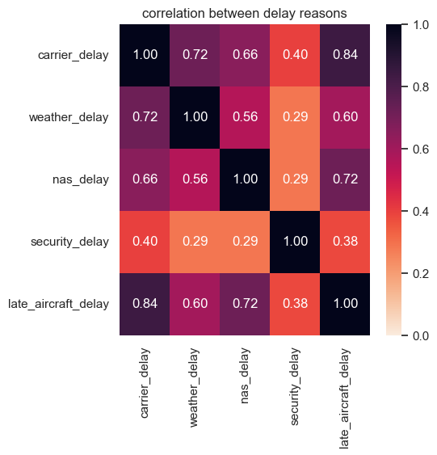

## Delay caused by various reasons

### Main reasons for delay in minutes

late_aircraft_delay

carrier_delay

nas_delay

### Main reasons for number of flights delayed

late_aircraft_ct

nas_delay_ct

carrier_ct

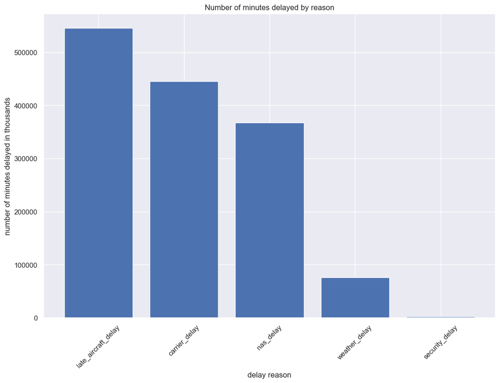

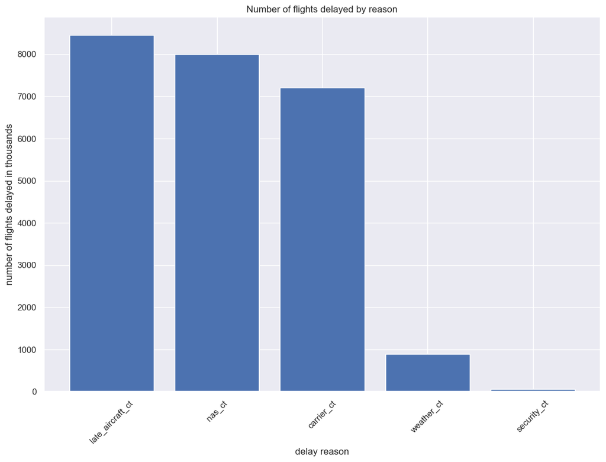